# Assignment 9: Hypothesis Testing and Power and Sample size Determination

Sean Schilk

4/7/2026

## **Question: New Cholesterol Medication**

A pharmaceutical company develops **“CholestFix”** to reduce Low-Density Lipoprotein (LDL, *fat carrier that’s low in density*) cholesterol. The **current standard drug** lowers LDL by an average of 25 mg/dL with a standard deviation of 15 mg/dL. A clinical trial with 5 participants were recruited in the study for three months. At the end of the study, the mean reduction is 29 mg/dL. Assume that the variance of LDL reduction of new drug is the same as that of the standard drugs.

Based on the results in the clinical trial, researchers in the company believe **CholestFix** is more effective.

a). Perform a formal hypothesis test of the researchers’ belief regarding LDL reduction, using a significance level of $\alpha = 0.05$.

```r
# Given information
xbar <- 29
mu0 <- 25
sigma <- 15
n <- 5

# z statistic
z <- (xbar - mu0) / (sigma / sqrt(n))
z
```

```
[1] 0.5962848
```

```r
# one-sided p-value
p_value <- 1 - pnorm(z)
p_value
```

```
[1] 0.2754925
```

We fail to reject the null hypothesis, and therefore lack sufficient evidence to conclude CholestFix is more effective at lowering LDL more than the current standard drug average of 25 mg/dL.

b). Given $n = 50, \sigma = 15, \alpha = 0.05$, and an effect size we wish to detect $\delta = 4$ mg/dL (corresponding to a reduction from 29 mg/dL to 25 mg/dL). What is the probability that we’d detect a true improvement?

```r
power_calc <- power.t.test(n = 50,
                          delta = 4,
                          sd = 15,
                          sig.level = 0.05,
                          type = "one.sample",
                          alternative = "one.sided")
print(power_calc$power)
```

```
[1] 0.5849737
```

c). Determine the minimum sample size required to detect an effect size of 4 mg/dL with a power of $1 - \beta = 0.8$ and a significance level of $\alpha = 0.05$. Assume the standard deviation of LDL reduction is 15 mg/dL.

```r
# Sample size calculation
sample_size <- power.t.test(power = 0.80,
                            delta = 4,
                           sd = 15,
                           sig.level = 0.05,
                           type = "one.sample",
                           alternative = "one.sided")
cat("\nRequired sample size for 80% power:", ceiling(sample_size$n))
```

```
Required sample size for 80% power: 89
```

d). **Power curve**: To assess the impact of sample size on power, we can create a power function in terms of the sample size $n$ and use the remaining information from part (b). Plot the power curve by selecting a sequence of sample sizes.

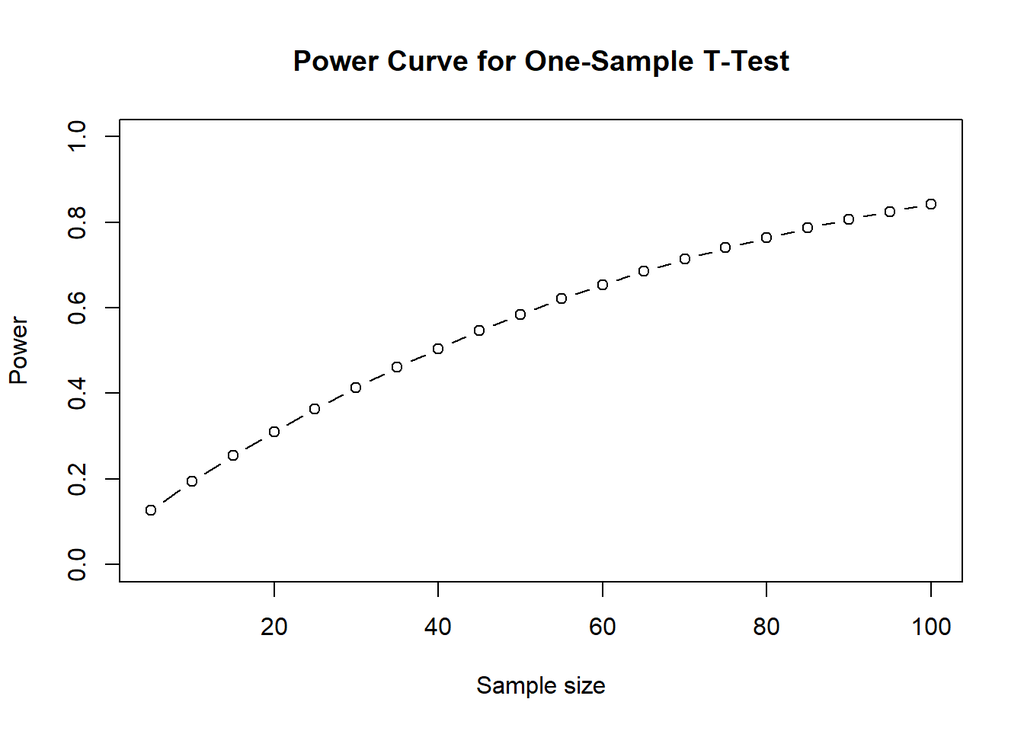

```r
power_function <- function(n) {
  power.t.test(n = n,
               delta = 4,
               sd = 15,
               sig.level = 0.05,
               type = "one.sample",
               alternative = "one.sided")$power
}

n <- seq(5, 100, by = 5)
power <- sapply(n, power_function)


plot(n, power, type = "b",
     xlab = "Sample size",
     ylab = "Power",
     main = "Power Curve for One-Sample T-Test",
     ylim = c(0, 1))
```